# Segmentación de Clientes de Tarjetas de Crédito

## Contexto y Problema de negocio

Un banco colombiano tiene datos de consumo de más de 47,000 tarjetahabientes, pero no cuenta con una forma de agrupar a estos clientes según cómo usan su tarjeta. Sin esa segmentación, las promociones se diseñan de manera genérica, sin aprovechar los patrones de consumo reales de cada tipo de cliente.

> ¿Cómo identificar qué grupos de clientes de tarjetas de crédito hay según su ocasión de consumo, y qué recomendaciones de negocio se pueden dar para diseñar promociones enfocadas en cada uno?

## Enfoque técnico

Dado que los grupos de clientes no se conocen previamente, se utiliza clustering — una técnica de aprendizaje no supervisado que identifica grupos a partir de patrones de comportamiento similares entre clientes.

```python
import pandas as pd
from google.colab import drive
drive.mount('/content/drive')
df = pd.read_excel('/content/drive/MyDrive/Colab Notebooks/Portfolio/Python_SQL/infoclientebanca.xlsx')
df.head()
```

|  | CLIENTE | grupo_de_cliente | Numero_de_transacciones | promedio_por_transaccion | transaccion_minima | transaccion_maxima | desviacion_estandar_por_transaccion | porcentaje_visa_nacional | porcentaje_visa_internacional | porcentaje_mastercard_nacional | ... | porcentaje_tarde | porcentaje_noche | porcDOMINGO | porcLUNES | porcMARTES | porcMIERCOLES | porcJUEVES | porcVIERNES | porcSABADO | Sitio_consumo_masfrecuente |
| --- | --- | --- | --- | --- | --- | --- | --- | --- | --- | --- | --- | --- | --- | --- | --- | --- | --- | --- | --- | --- | --- |
| 0 | 1 | A | 1 | 459930.3 | 459930.3 | 459930.3 | 0.00 | 0.0 | 1.0 | 0.0 | ... | 0.0 | 1.0 | 0.0 | 0.000000 | 1.0 | 0.0 | 0.000000 | 0.0 | 0.0 | CLINICAS - HOSPITALES |
| 1 | 2 | A | 3 | 582666.7 | 350000.0 | 699000.0 | 201495.23 | 1.0 | 0.0 | 0.0 | ... | 1.0 | 0.0 | 0.0 | 0.666667 | 0.0 | 0.0 | 0.333333 | 0.0 | 0.0 | MERCADEO DIRECTO - COMERCIANTES DE VENTAS TELE... |
| 2 | 3 | A | 3 | 616547.0 | 616547.0 | 616547.0 | 0.00 | 1.0 | 0.0 | 0.0 | ... | 0.0 | 0.0 | 0.0 | 0.000000 | 0.0 | 1.0 | 0.000000 | 0.0 | 0.0 | DROGUERIAS, FARMACIAS, TIENDAS NATURISTAS |
| 3 | 4 | A | 10 | 144467.1 | 20000.0 | 328444.0 | 116685.81 | 0.0 | 0.0 | 1.0 | ... | 0.6 | 0.0 | 0.0 | 0.600000 | 0.2 | 0.0 | 0.100000 | 0.0 | 0.1 | ALMACEN POR DEPARTAMENTO CON SUPERMERCADO |
| 4 | 5 | A | 1 | 321764.0 | 321764.0 | 321764.0 | 0.00 | 1.0 | 0.0 | 0.0 | ... | 1.0 | 0.0 | 1.0 | 0.000000 | 0.0 | 0.0 | 0.000000 | 0.0 | 0.0 | ALMACEN POR DEPARTAMENTO CON SUPERMERCADO |

5 rows × 26 columns

```python
#Elimino las variables no requeridas para el clustering y Sitio_consumo_masfrecuente, ya que será transformada posteriormente.
df_1= df.drop(['CLIENTE','grupo_de_cliente','Sitio_consumo_masfrecuente'],axis=1)
df_1.head()
```

|  | Numero_de_transacciones | promedio_por_transaccion | transaccion_minima | transaccion_maxima | desviacion_estandar_por_transaccion | porcentaje_visa_nacional | porcentaje_visa_internacional | porcentaje_mastercard_nacional | porcentaje_mastercard_internacional | Porcentaje_otrafranquicia_nacional | ... | porcentaje_manana | porcentaje_tarde | porcentaje_noche | porcDOMINGO | porcLUNES | porcMARTES | porcMIERCOLES | porcJUEVES | porcVIERNES | porcSABADO |
| --- | --- | --- | --- | --- | --- | --- | --- | --- | --- | --- | --- | --- | --- | --- | --- | --- | --- | --- | --- | --- | --- |
| 0 | 1 | 459930.3 | 459930.3 | 459930.3 | 0.00 | 0.0 | 1.0 | 0.0 | 0.0 | 0.0 | ... | 0.0 | 0.0 | 1.0 | 0.0 | 0.000000 | 1.0 | 0.0 | 0.000000 | 0.0 | 0.0 |
| 1 | 3 | 582666.7 | 350000.0 | 699000.0 | 201495.23 | 1.0 | 0.0 | 0.0 | 0.0 | 0.0 | ... | 0.0 | 1.0 | 0.0 | 0.0 | 0.666667 | 0.0 | 0.0 | 0.333333 | 0.0 | 0.0 |
| 2 | 3 | 616547.0 | 616547.0 | 616547.0 | 0.00 | 1.0 | 0.0 | 0.0 | 0.0 | 0.0 | ... | 1.0 | 0.0 | 0.0 | 0.0 | 0.000000 | 0.0 | 1.0 | 0.000000 | 0.0 | 0.0 |
| 3 | 10 | 144467.1 | 20000.0 | 328444.0 | 116685.81 | 0.0 | 0.0 | 1.0 | 0.0 | 0.0 | ... | 0.4 | 0.6 | 0.0 | 0.0 | 0.600000 | 0.2 | 0.0 | 0.100000 | 0.0 | 0.1 |
| 4 | 1 | 321764.0 | 321764.0 | 321764.0 | 0.00 | 1.0 | 0.0 | 0.0 | 0.0 | 0.0 | ... | 0.0 | 1.0 | 0.0 | 1.0 | 0.000000 | 0.0 | 0.0 | 0.000000 | 0.0 | 0.0 |

5 rows × 23 columns

```python
#Transformamo la variable 'Sitio_consumo_masfrecuente' de categórica a numérica con variables dummy.
df_2 = pd.get_dummies(df['Sitio_consumo_masfrecuente']).astype(int)
df_2.head()
```

|  | ADMINISTRACION DE AREAS COMUNES, SERVICIOS DE LIMPIEZA, MANTENIMIENTO Y CELADURIA | AEROLINEAS | AGENCIAS DE BOLETERIA ( Producciones de Teatro ) excepto cine | AGENCIAS DE PROTECCIÓN Y SERVICIOS DE SEGURIDAD | AGENCIAS DE VIAJE y OPERADORES DE TURISMO | ALMACEN DE BICICLETAS VENTA Y SERVICIOS | ALMACEN DE TAPETES, ALFOMBRAS Y PISOS | ALMACEN POR DEPARTAMENTO CON SUPERMERCADO | ALMACENES DE ARTICULOS DE CUERO Y MALETAS | ALMACENES DE ARTICULOS DEPORTIVOS | ... | TALLERES DE MECANICA Y LATONERIA Y PINTURA Y SERVICIIOS DE GRUA | TIENDAS DE ALQUILER DE VIDEOS | TRANSPORTE DE CARGA EN GENERAL | TRANSPORTE DE PASAJEROS, TERRESTRE, FLUVIAL y MARITIMO | VENTA DE EQUIPOS Y SERVICIOS DE TELECOMUNICACIONES | VENTA DE ARTICULOS MEDICOS, ODONTOLOGICOS, ORTOPEDICOS | VENTA DE COMIDA RAPIDA | VENTA DE BOTES Y ACCESORIOS PARA ACTIVIDADES ACUATICAS | VENTA DE VEHICULOS AUTOMOTORES Y MOTOCICLETAS | VIVEROS Y ALMACENES PARA JARDINERIA |
| --- | --- | --- | --- | --- | --- | --- | --- | --- | --- | --- | --- | --- | --- | --- | --- | --- | --- | --- | --- | --- | --- |
| 0 | 0 | 0 | 0 | 0 | 0 | 0 | 0 | 0 | 0 | 0 | ... | 0 | 0 | 0 | 0 | 0 | 0 | 0 | 0 | 0 | 0 |
| 1 | 0 | 0 | 0 | 0 | 0 | 0 | 0 | 0 | 0 | 0 | ... | 0 | 0 | 0 | 0 | 0 | 0 | 0 | 0 | 0 | 0 |
| 2 | 0 | 0 | 0 | 0 | 0 | 0 | 0 | 0 | 0 | 0 | ... | 0 | 0 | 0 | 0 | 0 | 0 | 0 | 0 | 0 | 0 |
| 3 | 0 | 0 | 0 | 0 | 0 | 0 | 0 | 1 | 0 | 0 | ... | 0 | 0 | 0 | 0 | 0 | 0 | 0 | 0 | 0 | 0 |
| 4 | 0 | 0 | 0 | 0 | 0 | 0 | 0 | 1 | 0 | 0 | ... | 0 | 0 | 0 | 0 | 0 | 0 | 0 | 0 | 0 | 0 |

5 rows × 109 columns

```python
#Uno los dos dataframes.
df_cluster=pd.concat([df_1,df_2],axis=1)
df_cluster.head()
```

|  | Numero_de_transacciones | promedio_por_transaccion | transaccion_minima | transaccion_maxima | desviacion_estandar_por_transaccion | porcentaje_visa_nacional | porcentaje_visa_internacional | porcentaje_mastercard_nacional | porcentaje_mastercard_internacional | Porcentaje_otrafranquicia_nacional | ... | TALLERES DE MECANICA Y LATONERIA Y PINTURA Y SERVICIIOS DE GRUA | TIENDAS DE ALQUILER DE VIDEOS | TRANSPORTE DE CARGA EN GENERAL | TRANSPORTE DE PASAJEROS, TERRESTRE, FLUVIAL y MARITIMO | VENTA DE EQUIPOS Y SERVICIOS DE TELECOMUNICACIONES | VENTA DE ARTICULOS MEDICOS, ODONTOLOGICOS, ORTOPEDICOS | VENTA DE COMIDA RAPIDA | VENTA DE BOTES Y ACCESORIOS PARA ACTIVIDADES ACUATICAS | VENTA DE VEHICULOS AUTOMOTORES Y MOTOCICLETAS | VIVEROS Y ALMACENES PARA JARDINERIA |
| --- | --- | --- | --- | --- | --- | --- | --- | --- | --- | --- | --- | --- | --- | --- | --- | --- | --- | --- | --- | --- | --- |
| 0 | 1 | 459930.3 | 459930.3 | 459930.3 | 0.00 | 0.0 | 1.0 | 0.0 | 0.0 | 0.0 | ... | 0 | 0 | 0 | 0 | 0 | 0 | 0 | 0 | 0 | 0 |
| 1 | 3 | 582666.7 | 350000.0 | 699000.0 | 201495.23 | 1.0 | 0.0 | 0.0 | 0.0 | 0.0 | ... | 0 | 0 | 0 | 0 | 0 | 0 | 0 | 0 | 0 | 0 |
| 2 | 3 | 616547.0 | 616547.0 | 616547.0 | 0.00 | 1.0 | 0.0 | 0.0 | 0.0 | 0.0 | ... | 0 | 0 | 0 | 0 | 0 | 0 | 0 | 0 | 0 | 0 |
| 3 | 10 | 144467.1 | 20000.0 | 328444.0 | 116685.81 | 0.0 | 0.0 | 1.0 | 0.0 | 0.0 | ... | 0 | 0 | 0 | 0 | 0 | 0 | 0 | 0 | 0 | 0 |
| 4 | 1 | 321764.0 | 321764.0 | 321764.0 | 0.00 | 1.0 | 0.0 | 0.0 | 0.0 | 0.0 | ... | 0 | 0 | 0 | 0 | 0 | 0 | 0 | 0 | 0 | 0 |

5 rows × 132 columns

```python
#Normalizamos los datos, para que todas las variables queden en la misma escala y sean comparables.
from sklearn.preprocessing import StandardScaler
scaler = StandardScaler()
array_norm = scaler.fit_transform(df_cluster)
```

### Aplicación de Elbow Method para determinar el número óptimo de clusters.

```python
#Evalúo de 1 a 6 clusters.
from sklearn.cluster import KMeans
inercias = []
for k in range (1,7):
  kmeans = KMeans(n_clusters=k, random_state=42)
  kmeans.fit(array_norm)
  inercias.append(kmeans.inertia_)
```

```python
#Libreria Gráficos
import matplotlib.pyplot as plt
# Paleta de colores
color_principal = '#f4df52'
colores_clusters = ['#f4df52', '#6940c9', '#D9BC07', '#9b7cff']
```

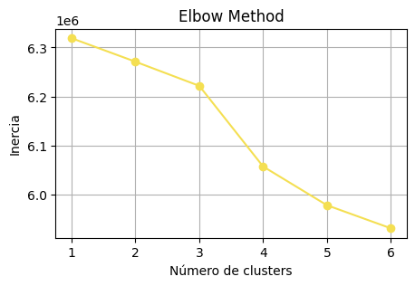

```python
#Grafico la inercia para identificar el número óptimo de clusters.
plt.figure(figsize=(5, 3))
plt.plot(range(1,7), inercias, marker='o', color=color_principal)
plt.xlabel('Número de clusters')
plt.ylabel('Inercia')
plt.title('Elbow Method')
plt.grid(True)
plt.show()
```

**Conclusión:** Se seleccionan **4 clusters** como número óptimo, ya que a partir de este punto la reducción de la inercia no es significativa, y 4 clusters permite una segmentación manejable de los clientes.

```python
#Creo y entreno el modelo final con 4 clusters.
Kmeans_final = KMeans(n_clusters=4, random_state=42)
Kmeans_final.fit(array_norm)
```

```
KMeans(n_clusters=4, random_state=42)
```

```python
#Agrego una columna en el dataframe que indique a que cluster pertenece cada cliente.
df_cluster['cluster'] = Kmeans_final.labels_
df_cluster.head()
```

|  | Numero_de_transacciones | promedio_por_transaccion | transaccion_minima | transaccion_maxima | desviacion_estandar_por_transaccion | porcentaje_visa_nacional | porcentaje_visa_internacional | porcentaje_mastercard_nacional | porcentaje_mastercard_internacional | Porcentaje_otrafranquicia_nacional | ... | TIENDAS DE ALQUILER DE VIDEOS | TRANSPORTE DE CARGA EN GENERAL | TRANSPORTE DE PASAJEROS, TERRESTRE, FLUVIAL y MARITIMO | VENTA DE EQUIPOS Y SERVICIOS DE TELECOMUNICACIONES | VENTA DE ARTICULOS MEDICOS, ODONTOLOGICOS, ORTOPEDICOS | VENTA DE COMIDA RAPIDA | VENTA DE BOTES Y ACCESORIOS PARA ACTIVIDADES ACUATICAS | VENTA DE VEHICULOS AUTOMOTORES Y MOTOCICLETAS | VIVEROS Y ALMACENES PARA JARDINERIA | cluster |
| --- | --- | --- | --- | --- | --- | --- | --- | --- | --- | --- | --- | --- | --- | --- | --- | --- | --- | --- | --- | --- | --- |
| 0 | 1 | 459930.3 | 459930.3 | 459930.3 | 0.00 | 0.0 | 1.0 | 0.0 | 0.0 | 0.0 | ... | 0 | 0 | 0 | 0 | 0 | 0 | 0 | 0 | 0 | 3 |
| 1 | 3 | 582666.7 | 350000.0 | 699000.0 | 201495.23 | 1.0 | 0.0 | 0.0 | 0.0 | 0.0 | ... | 0 | 0 | 0 | 0 | 0 | 0 | 0 | 0 | 0 | 0 |
| 2 | 3 | 616547.0 | 616547.0 | 616547.0 | 0.00 | 1.0 | 0.0 | 0.0 | 0.0 | 0.0 | ... | 0 | 0 | 0 | 0 | 0 | 0 | 0 | 0 | 0 | 0 |
| 3 | 10 | 144467.1 | 20000.0 | 328444.0 | 116685.81 | 0.0 | 0.0 | 1.0 | 0.0 | 0.0 | ... | 0 | 0 | 0 | 0 | 0 | 0 | 0 | 0 | 0 | 0 |
| 4 | 1 | 321764.0 | 321764.0 | 321764.0 | 0.00 | 1.0 | 0.0 | 0.0 | 0.0 | 0.0 | ... | 0 | 0 | 0 | 0 | 0 | 0 | 0 | 0 | 0 | 0 |

5 rows × 133 columns

```python
#Calculo el promedio de las variables para cada cluster.
df_cluster.groupby('cluster').mean().round(2)
```

| cluster | Numero_de_transacciones | promedio_por_transaccion | transaccion_minima | transaccion_maxima | desviacion_estandar_por_transaccion | porcentaje_visa_nacional | porcentaje_visa_internacional | porcentaje_mastercard_nacional | porcentaje_mastercard_internacional | Porcentaje_otrafranquicia_nacional | ... | TALLERES DE MECANICA Y LATONERIA Y PINTURA Y SERVICIIOS DE GRUA | TIENDAS DE ALQUILER DE VIDEOS | TRANSPORTE DE CARGA EN GENERAL | TRANSPORTE DE PASAJEROS, TERRESTRE, FLUVIAL y MARITIMO | VENTA DE EQUIPOS Y SERVICIOS DE TELECOMUNICACIONES | VENTA DE ARTICULOS MEDICOS, ODONTOLOGICOS, ORTOPEDICOS | VENTA DE COMIDA RAPIDA | VENTA DE BOTES Y ACCESORIOS PARA ACTIVIDADES ACUATICAS | VENTA DE VEHICULOS AUTOMOTORES Y MOTOCICLETAS | VIVEROS Y ALMACENES PARA JARDINERIA |
| --- | --- | --- | --- | --- | --- | --- | --- | --- | --- | --- | --- | --- | --- | --- | --- | --- | --- | --- | --- | --- | --- |
| 0 | 4.86 | 340235.36 | 240388.87 | 515901.50 | 118324.94 | 0.40 | 0.00 | 0.58 | 0.00 | 0.01 | ... | 0.0 | 0.0 | 0.0 | 0.0 | 0.03 | 0.0 | 0.01 | 0.0 | 0.01 | 0.0 |
| 1 | 2.66 | 881663.03 | 739606.84 | 1039652.81 | 153363.55 | 0.37 | 0.01 | 0.58 | 0.03 | 0.01 | ... | 0.0 | 0.0 | 0.0 | 0.0 | 0.00 | 0.0 | 0.00 | 0.0 | 0.00 | 0.0 |
| 2 | 3.68 | 945138.91 | 725904.97 | 1224787.22 | 237642.01 | 0.39 | 0.01 | 0.58 | 0.01 | 0.01 | ... | 0.0 | 0.0 | 0.0 | 0.0 | 0.00 | 0.0 | 0.00 | 0.0 | 0.00 | 0.0 |
| 3 | 7.81 | 670061.18 | 344680.62 | 1262244.63 | 380793.55 | 0.08 | 0.41 | 0.11 | 0.29 | 0.00 | ... | 0.0 | 0.0 | 0.0 | 0.0 | 0.01 | 0.0 | 0.00 | 0.0 | 0.01 | 0.0 |

4 rows × 132 columns

### Parte 2: Análisis de clusters mediante SQL

```python
#Creo otro dataframe donde la variable 'Sitio_consumo_masfrecuente' no haya sido transformada ni eliminada.
#Elimino las columans que no necesito: 'CLIENTE'y 'grupo_de_cliente'.
df_3 = df.drop(['CLIENTE','grupo_de_cliente'],axis=1)
df_3.head()
```

|  | Numero_de_transacciones | promedio_por_transaccion | transaccion_minima | transaccion_maxima | desviacion_estandar_por_transaccion | porcentaje_visa_nacional | porcentaje_visa_internacional | porcentaje_mastercard_nacional | porcentaje_mastercard_internacional | Porcentaje_otrafranquicia_nacional | ... | porcentaje_tarde | porcentaje_noche | porcDOMINGO | porcLUNES | porcMARTES | porcMIERCOLES | porcJUEVES | porcVIERNES | porcSABADO | Sitio_consumo_masfrecuente |
| --- | --- | --- | --- | --- | --- | --- | --- | --- | --- | --- | --- | --- | --- | --- | --- | --- | --- | --- | --- | --- | --- |
| 0 | 1 | 459930.3 | 459930.3 | 459930.3 | 0.00 | 0.0 | 1.0 | 0.0 | 0.0 | 0.0 | ... | 0.0 | 1.0 | 0.0 | 0.000000 | 1.0 | 0.0 | 0.000000 | 0.0 | 0.0 | CLINICAS - HOSPITALES |
| 1 | 3 | 582666.7 | 350000.0 | 699000.0 | 201495.23 | 1.0 | 0.0 | 0.0 | 0.0 | 0.0 | ... | 1.0 | 0.0 | 0.0 | 0.666667 | 0.0 | 0.0 | 0.333333 | 0.0 | 0.0 | MERCADEO DIRECTO - COMERCIANTES DE VENTAS TELE... |
| 2 | 3 | 616547.0 | 616547.0 | 616547.0 | 0.00 | 1.0 | 0.0 | 0.0 | 0.0 | 0.0 | ... | 0.0 | 0.0 | 0.0 | 0.000000 | 0.0 | 1.0 | 0.000000 | 0.0 | 0.0 | DROGUERIAS, FARMACIAS, TIENDAS NATURISTAS |
| 3 | 10 | 144467.1 | 20000.0 | 328444.0 | 116685.81 | 0.0 | 0.0 | 1.0 | 0.0 | 0.0 | ... | 0.6 | 0.0 | 0.0 | 0.600000 | 0.2 | 0.0 | 0.100000 | 0.0 | 0.1 | ALMACEN POR DEPARTAMENTO CON SUPERMERCADO |
| 4 | 1 | 321764.0 | 321764.0 | 321764.0 | 0.00 | 1.0 | 0.0 | 0.0 | 0.0 | 0.0 | ... | 1.0 | 0.0 | 1.0 | 0.000000 | 0.0 | 0.0 | 0.000000 | 0.0 | 0.0 | ALMACEN POR DEPARTAMENTO CON SUPERMERCADO |

5 rows × 24 columns

```python
#Agrego una columna en el dataframe que indique a que cluster pertenece cada cliente.
df_3['cluster'] = Kmeans_final.labels_
df_3.head()
```

|  | Numero_de_transacciones | promedio_por_transaccion | transaccion_minima | transaccion_maxima | desviacion_estandar_por_transaccion | porcentaje_visa_nacional | porcentaje_visa_internacional | porcentaje_mastercard_nacional | porcentaje_mastercard_internacional | Porcentaje_otrafranquicia_nacional | ... | porcentaje_noche | porcDOMINGO | porcLUNES | porcMARTES | porcMIERCOLES | porcJUEVES | porcVIERNES | porcSABADO | Sitio_consumo_masfrecuente | cluster |
| --- | --- | --- | --- | --- | --- | --- | --- | --- | --- | --- | --- | --- | --- | --- | --- | --- | --- | --- | --- | --- | --- |
| 0 | 1 | 459930.3 | 459930.3 | 459930.3 | 0.00 | 0.0 | 1.0 | 0.0 | 0.0 | 0.0 | ... | 1.0 | 0.0 | 0.000000 | 1.0 | 0.0 | 0.000000 | 0.0 | 0.0 | CLINICAS - HOSPITALES | 3 |
| 1 | 3 | 582666.7 | 350000.0 | 699000.0 | 201495.23 | 1.0 | 0.0 | 0.0 | 0.0 | 0.0 | ... | 0.0 | 0.0 | 0.666667 | 0.0 | 0.0 | 0.333333 | 0.0 | 0.0 | MERCADEO DIRECTO - COMERCIANTES DE VENTAS TELE... | 0 |
| 2 | 3 | 616547.0 | 616547.0 | 616547.0 | 0.00 | 1.0 | 0.0 | 0.0 | 0.0 | 0.0 | ... | 0.0 | 0.0 | 0.000000 | 0.0 | 1.0 | 0.000000 | 0.0 | 0.0 | DROGUERIAS, FARMACIAS, TIENDAS NATURISTAS | 0 |
| 3 | 10 | 144467.1 | 20000.0 | 328444.0 | 116685.81 | 0.0 | 0.0 | 1.0 | 0.0 | 0.0 | ... | 0.0 | 0.0 | 0.600000 | 0.2 | 0.0 | 0.100000 | 0.0 | 0.1 | ALMACEN POR DEPARTAMENTO CON SUPERMERCADO | 0 |
| 4 | 1 | 321764.0 | 321764.0 | 321764.0 | 0.00 | 1.0 | 0.0 | 0.0 | 0.0 | 0.0 | ... | 0.0 | 1.0 | 0.000000 | 0.0 | 0.0 | 0.000000 | 0.0 | 0.0 | ALMACEN POR DEPARTAMENTO CON SUPERMERCADO | 0 |

5 rows × 25 columns

```python
#Creo la base de datos SQLite y almaceno los datos de los clientes.
import sqlite3

conn = sqlite3.connect('banco.db')
df_3.to_sql('clientes', conn, if_exists='replace', index=False)
```

```
47871
```

```python
#Consulta 1: Identifico el Sitio_consumo_masfrecuente de cada cluster y calculo el número de clientes que hay en ese grupo.
query = """
SELECT cluster, Sitio_consumo_masfrecuente, total
FROM (
    SELECT cluster, Sitio_consumo_masfrecuente, COUNT(*) as total,
           ROW_NUMBER() OVER (PARTITION BY cluster ORDER BY COUNT(*) DESC) as rn
    FROM clientes
    GROUP BY cluster, Sitio_consumo_masfrecuente
)
WHERE rn = 1
"""
#Creo el dataframe 'resultado' para almacenar los resultados de la consulta.
resultado = pd.read_sql_query(query, conn)
resultado.head()
```

|  | cluster | Sitio_consumo_masfrecuente | total |
| --- | --- | --- | --- |
| 0 | 0 | SUPERMERCADOS / TIENDAS EXPRESS | 8922 |
| 1 | 1 | ALMACENES DE ELECTRODOMESTICOS Y GASODOMESTICOS | 128 |
| 2 | 2 | MUEBLES PARA EL HOGAR y OFICINA | 310 |
| 3 | 3 | COMPRAS EN INTERNET | 1044 |

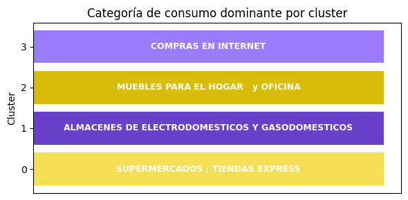

```python
plt.figure(figsize=(6, 3))
plt.barh(resultado['cluster'].astype(str), [1]*len(resultado), color=colores_clusters)
plt.ylabel('Cluster')
plt.xticks([])
plt.title('Categoría de consumo dominante por cluster')

for i, sitio in enumerate(resultado['Sitio_consumo_masfrecuente']):
    plt.text(0.5, i, sitio, ha='center', va='center', color='white',
              fontweight='bold', fontsize=9)

plt.tight_layout()
plt.show()
```

```python
#Consulta 2: Calculo el número de clientes y su porcentaje de participación dentro de cada cluster.
query = """
SELECT cluster, COUNT(cluster) as num_clientes,
ROUND((COUNT(cluster)*100.0/(SELECT COUNT(cluster) FROM clientes)),2) as porcentaje
FROM clientes
GROUP BY cluster
"""
resultado2 = pd.read_sql_query(query, conn)
resultado2['porcentaje'] = resultado2['porcentaje'].astype(str) + '%'
resultado2.head()
```

|  | cluster | num_clientes | porcentaje |
| --- | --- | --- | --- |
| 0 | 0 | 43659 | 91.2% |
| 1 | 1 | 128 | 0.27% |
| 2 | 2 | 310 | 0.65% |
| 3 | 3 | 3774 | 7.88% |

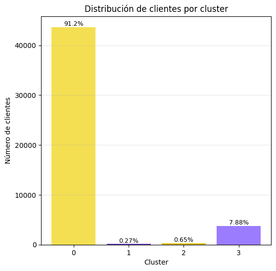

```python
plt.figure(figsize=(6, 6))
barras = plt.bar(resultado2['cluster'].astype(str), resultado2['num_clientes'], color=colores_clusters)
plt.xlabel('Cluster')
plt.ylabel('Número de clientes')
plt.title('Distribución de clientes por cluster')
plt.grid(True, axis='y', alpha=0.3)

for barra, porcentaje in zip(barras, resultado2['porcentaje']):
    plt.text(barra.get_x() + barra.get_width()/2, barra.get_height(),
              porcentaje, ha='center', va='bottom', fontsize=9)

plt.show()
```

**Conclusión:** El cluster 0 concentra el 91% de los clientes, es un grupo demasiado grande para representar un solo perfil homogéneo de clientes.

> Como próximo paso, aplico un segundo K-means únicamente sobre los clientes del cluster 0, para subdividirlo en segmentos más específicos (sub-clustering).

### Sub-Clustering del Cluster 0

```python
#Creo un nuevo array que guarde solo los datos del cluster 0.
array_norm2 = array_norm[df_cluster['cluster'] == 0]

#Evalúo de 1 a 6 clusters, solo para los clientes del cluster 0.
inercias2 = []
for k in range (1,7):
  kmeans2 = KMeans(n_clusters=k, random_state=42)
  kmeans2.fit(array_norm2)
  inercias2.append(kmeans2.inertia_)
```

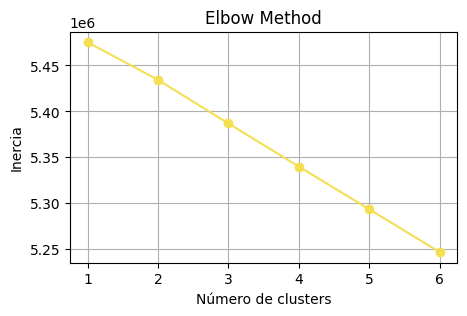

```python
#Grafico la inercia para identificar el número óptimo de clusters.
plt.figure(figsize=(5, 3))
plt.plot(range(1,7),inercias2,marker='o',color=color_principal)
plt.xlabel('Número de clusters')
plt.ylabel('Inercia')
plt.title('Elbow Method')
plt.grid(True)
plt.show()
```

**Conclusión del sub-clustering:** La curva de inercia del cluster 0 no muestra un codo definido, sino una caída gradual — indica que este grupo, aunque concentra el 91% de los clientes, es internamente homogéneo y no justifica dividirse más.

> Por lo tanto, se mantiene la segmentación original de 4 clusters.

```python
#Calculo el monto promedio por transacción de cada clúster.
promedio_transaccion = df_cluster.groupby('cluster')['promedio_por_transaccion'].mean()
promedio_transaccion
```

| cluster | promedio_por_transaccion |
| --- | --- |
| 0 | 340235.356911 |
| 1 | 881663.030078 |
| 2 | 945138.911032 |
| 3 | 670061.181592 |

**dtype:** float64

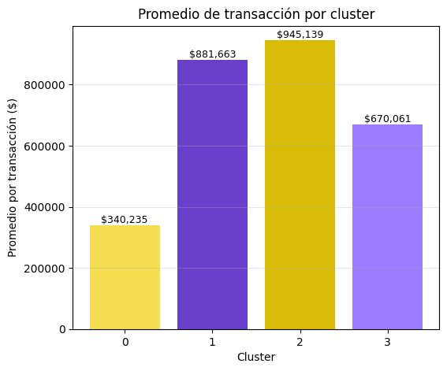

```python
plt.figure(figsize=(6, 5))
barras = plt.bar(promedio_transaccion.index.astype(str), promedio_transaccion.values, color=colores_clusters)
plt.xlabel('Cluster')
plt.ylabel('Promedio por transacción ($)')
plt.title('Promedio de transacción por cluster')
plt.grid(True, axis='y', alpha=0.3)

for barra, valor in zip(barras, promedio_transaccion.values):
    plt.text(barra.get_x() + barra.get_width()/2, barra.get_height(),
              f'${valor:,.0f}', ha='center', va='bottom', fontsize=9)

plt.show()
```

```python
#Consulta 3: Porcentaje promedio de transacciones realizadas con cada franquicia (Visa, Mastercard, otra) por cluster.
query = """
SELECT cluster,
AVG(porcentaje_visa_nacional + porcentaje_visa_internacional) as promedio_visa,
AVG(porcentaje_mastercard_nacional + porcentaje_mastercard_internacional) as promedio_mastercard,
AVG(Porcentaje_otrafranquicia_nacional + porcentaje_otrafranquicia_internacional) as promedio_otrafranquicia
FROM clientes
GROUP BY cluster
"""
resultado3 = pd.read_sql_query(query, conn)
resultado3.head()
```

|  | cluster | promedio_visa | promedio_mastercard | promedio_otrafranquicia |
| --- | --- | --- | --- | --- |
| 0 | 0 | 0.404227 | 0.579854 | 0.015919 |
| 1 | 1 | 0.380854 | 0.608599 | 0.010547 |
| 2 | 2 | 0.398348 | 0.586637 | 0.015015 |
| 3 | 3 | 0.495656 | 0.400953 | 0.103391 |

```python
#Identifico la franquicia más usada por cluster.
resultado3['tarjeta_mas_usada'] = resultado3[['promedio_visa', 'promedio_mastercard', 'promedio_otrafranquicia']].idxmax(axis=1)
resultado3['promedio_maximo'] = resultado3[['promedio_visa', 'promedio_mastercard', 'promedio_otrafranquicia']].max(axis=1)

#Dejo solo las columnas relevantes para graficar.
resultado3_final = resultado3[['cluster', 'tarjeta_mas_usada', 'promedio_maximo']]
resultado3_final.head()
```

|  | cluster | tarjeta_mas_usada | promedio_maximo |
| --- | --- | --- | --- |
| 0 | 0 | promedio_mastercard | 0.579854 |
| 1 | 1 | promedio_mastercard | 0.608599 |
| 2 | 2 | promedio_mastercard | 0.586637 |
| 3 | 3 | promedio_visa | 0.495656 |

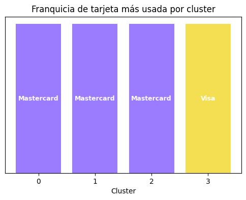

```python
plt.figure(figsize=(6, 4))
colores_franquicia = ['#9b7cff', '#9b7cff', '#9b7cff', '#f4df52']
plt.bar(resultado3_final['cluster'].astype(str), [1]*len(resultado3_final), color=colores_franquicia)
plt.xlabel('Cluster')
plt.yticks([])
plt.title('Franquicia de tarjeta más usada por cluster')

for i, tarjeta in enumerate(resultado3_final['tarjeta_mas_usada']):
    plt.text(i, 0.5, tarjeta.replace('promedio_', '').capitalize(),
             ha='center', va='center', color='white', fontweight='bold', fontsize=9)
plt.show()
```

```python
#Calculo el promedio de consumo nacional e internacional por cluster.
nacional_internacional = df_cluster.groupby('cluster')[['porcentaje_nacional_total', 'porcentaje_internacional_total']].mean()
nacional_internacional
```

| cluster | porcentaje_nacional_total | porcentaje_internacional_total |
| --- | --- | --- |
| 0 | 0.991212 | 0.008788 |
| 1 | 0.953999 | 0.046001 |
| 2 | 0.976891 | 0.023109 |
| 3 | 0.192881 | 0.807119 |

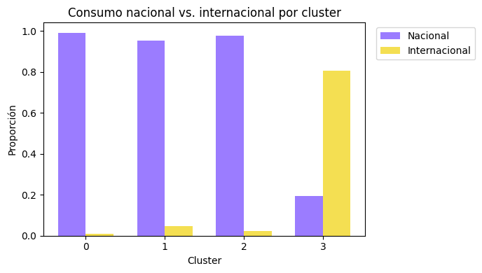

```python
import numpy as np
clusters = nacional_internacional.index.astype(str)
nac = nacional_internacional['porcentaje_nacional_total']
inter = nacional_internacional['porcentaje_internacional_total']
x = np.arange(len(clusters))
width = 0.35

fig, ax = plt.subplots(figsize=(7, 4))
rects1 = ax.bar(x - width/2, nac, width, label='Nacional', color='#9b7cff')
rects2 = ax.bar(x + width/2, inter, width, label='Internacional', color='#f4df52')

ax.set_xlabel('Cluster')
ax.set_ylabel('Proporción')
ax.set_title('Consumo nacional vs. internacional por cluster')
ax.set_xticks(x)
ax.set_xticklabels(clusters)
ax.legend(bbox_to_anchor=(1.02, 1), loc='upper left')  # Leyenda fuera del gráfico
plt.tight_layout()
plt.show()
```

```python
#Calculo el promedio de consumo en diferentes horas del día por cluster.
horario = df_cluster.groupby('cluster')[['porcentaje_manana', 'porcentaje_tarde', 'porcentaje_noche']].mean()
```

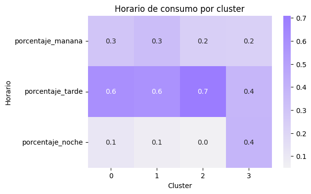

```python
import seaborn as sns

cmap_morado = sns.light_palette("#9b7cff", as_cmap=True)
plt.figure(figsize=(6, 4))
sns.heatmap(horario.T, annot=True, fmt='.1f', cmap=cmap_morado)
plt.xlabel('Cluster')
plt.ylabel('Horario')
plt.title('Horario de consumo por cluster')
plt.show()
```

**Observación:** El horario de la **tarde** domina en todos los clusters, especialmente en el cluster 2 (70%). El cluster 3 es el único con consumo nocturno significativo (40%), consistente con su perfil de compras en internet.

```python
#Calculo el promedio de consumo en diferentes días de la semana por cluster.
dias_semana = df_cluster.groupby('cluster')[['porcDOMINGO', 'porcLUNES', 'porcMARTES', 'porcMIERCOLES',
                                                'porcJUEVES', 'porcVIERNES', 'porcSABADO']].mean()
```

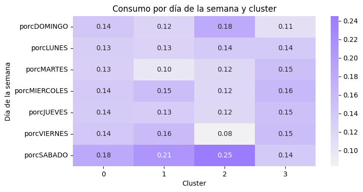

```python
cmap_morado = sns.light_palette("#9b7cff", as_cmap=True)
plt.figure(figsize=(8, 4))
sns.heatmap(dias_semana.T, annot=True, fmt='.2f', cmap=cmap_morado)
plt.xlabel('Cluster')
plt.ylabel('Día de la semana')
plt.title('Consumo por día de la semana y cluster')
plt.show()
```

## Análisis Final

> El clúster 0 es el más grande, ya que reúne al 91,2 % de los clientes. A pesar de su tamaño, presenta un comportamiento relativamente homogéneo, lo que indica que la mayoría de los clientes del banco comparten patrones de compra similares. La tarjeta más utilizada en este clúster es MasterCard y predominan las compras nacionales en la categoría de “Supermercados o Tiendas Express”, lo cual es consistente con su promedio por transacción, el más bajo entre los clústeres ($340.235). En cuanto al momento de compra, este clúster concentra principalmente sus compras en horas de la tarde y durante los sábados, aunque mantiene un nivel de consumo relativamente uniforme durante el resto de la semana.

> El clúster 1 es el más pequeño de todos, representa el 0,27 % de los clientes. La tarjeta más utilizada en este clúster es MasterCard y predominan las compras nacionales en la categoría de “Almacenes de electrodomésticos y gasodomésticos”, lo cual es consistente con su promedio por transacción que es el segundo más alto ($881.663). En cuanto al momento de compra, este clúster concentra principalmente sus compras en horas de la tarde y durante los sábados.

> El clúster 2 representa el 0,65 % de los clientes. La tarjeta más utilizada en este clúster es Mastercard y predominan las compras nacionales en la categoría de “Muebles para el hogar y oficina”, lo cual es consistente con su promedio por transacción que es el más alto ($945.139). En cuanto al momento de compra, este clúster concentra principalmente sus compras en horas de la tarde y durante los sábados, y los domingos en menor medida.

> El clúster 3 es el segundo más grande agrupando al 7,88 % de los clientes. La tarjeta más utilizada en este clúster es Visa y predominan las compras internacionales en la categoría de “Compras en internet”, su promedio por transacción es el tercero más alto ($670.061). En cuanto al momento de compra, este clúster concentra principalmente sus compras en igual medida tanto en la tarde como en la noche, y su consumo es uniforme durante todos los días de la semana.

> Los tres primeros clústeres usan como tarjeta preferida Mastercard y realizan mayormente compras nacionales, concentrando su consumo en horas de la tarde y los sábados. El clúster 3, en cambio, rompe con este patrón, es el único que prefiere Visa, realiza principalmente compras internacionales, y al ser el segundo clúster más grande (7,88%), representa una oportunidad relevante para diseñar estrategias diferenciadas.

## Recomendaciones de negocio

> Para el clúster 0, se recomienda una promoción con la tarjeta Mastercard en la categoría de Supermercados y Tiendas Express, alineada con su patrón de consumo dominante.

> Para el clúster 3, se recomienda una promoción con la tarjeta Visa en la categoría de Compras en Internet. Sin embargo, esta categoría es demasiado amplia para diseñar una promoción específica, por lo que, se sugiere un análisis adicional para identificar qué tipo de productos compra este segmento en línea,y definir mejor la estrategia.

```python
!jupyter nbconvert --to html --embed-images "/content/drive/MyDrive/Colab Notebooks/Portfolio/Python_SQL/ConsumoTarjetasCredito.ipynb"
```

```
[NbConvertApp] Converting notebook /content/drive/MyDrive/Colab Notebooks/Portfolio/Python_SQL/ConsumoTarjetasCredito.ipynb to html
[NbConvertApp] Writing 348787 bytes to /content/drive/MyDrive/Colab Notebooks/Portfolio/Python_SQL/ConsumoTarjetasCredito.html
```